# PlotSvalbard - User Manual

Plot research data from Svalbard on maps

Mikko Vihtakari

mikko.vihtakari@gmail.com

26 oktober, 2018

[**PlotSvalbard**](https://github.com/MikkoVihtakari/PlotSvalbard) package provides functions to plot research data from Svalbard on high resolution maps in [R](https://www.r-project.org/). The package is based on [ggplot2](http://ggplot2.tidyverse.org/reference/) and the functions can be expanded using ggplot syntax. The package contains also maps from other places in the Arctic, including polar stereographic maps of the Arctic.

The maps in PlotSvalbard are designed to be printed on `pdf()` device. If you need the maps for other devices, see the Graphical parameters section.

# Basemap

The `basemap` function is the generic plotting command in PlotSvalbard, and is analogous to empty `ggplot()` call. The `basemap()` call plots a map that is specified by the `type` argument. Data containing geographic information can be plotted on these maps using the [ggplot2 layers separated by the `+` operator](http://ggplot2.tidyverse.org/reference/).

## Map types

Map types are specified by the `type` argument in `basemap()` function. The list below shows all currently implemented map types.

### Svalbard

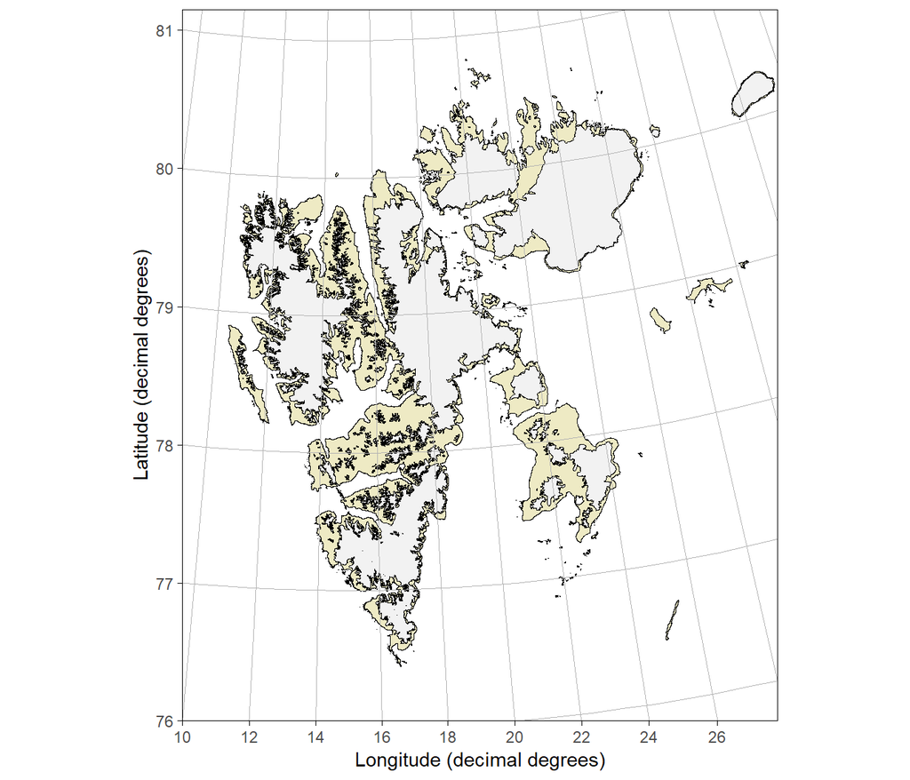

```r
library(PlotSvalbard)
basemap("svalbard")
```

#### Kongsfjorden

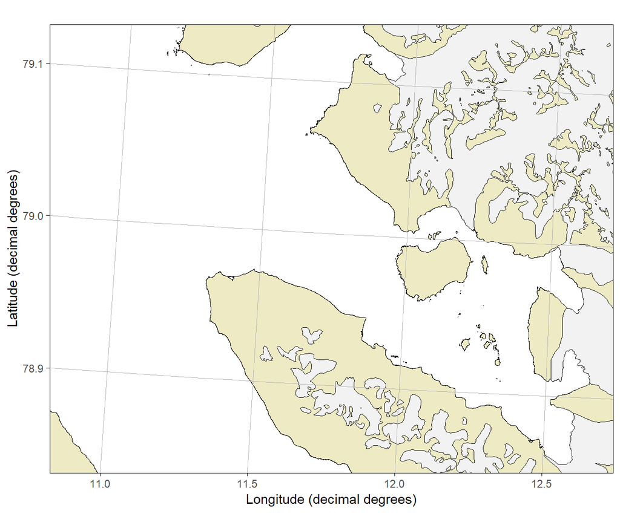

```r
basemap("kongsfjorden") # or just basemap()
```

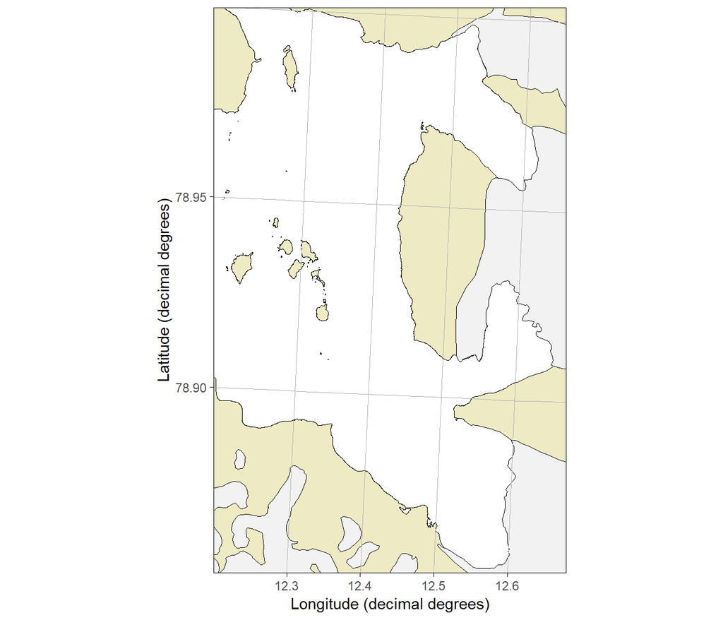

```r
basemap("kongsfjordbotn")
```

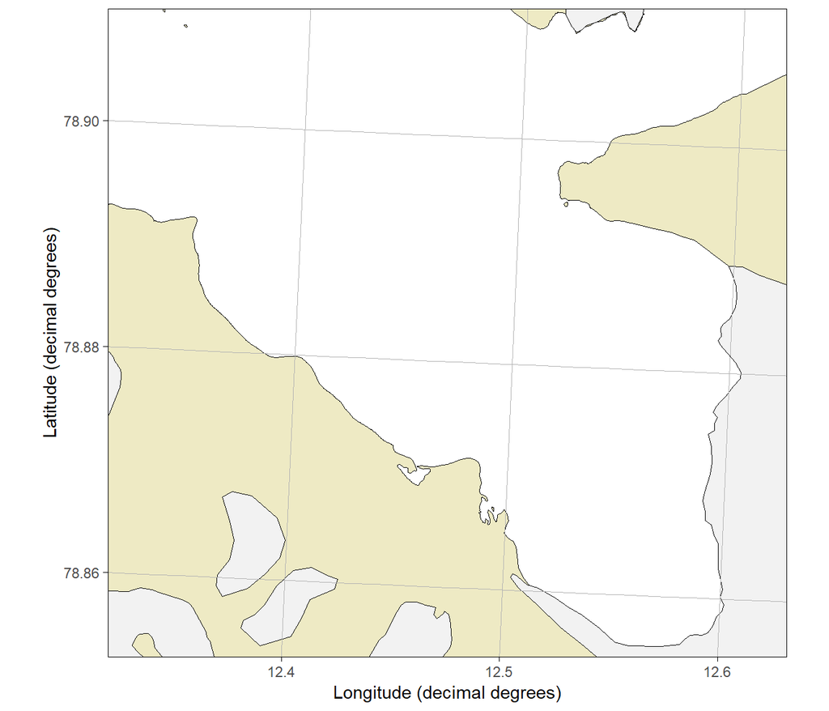

```r
basemap("kronebreen")
```

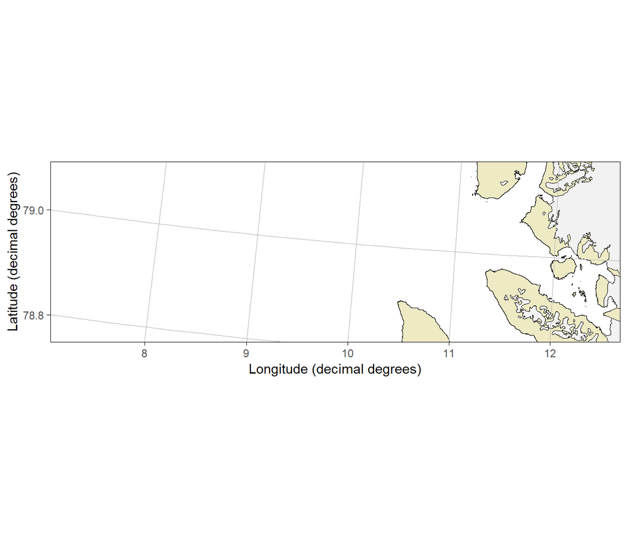

```r
basemap("mosj")
```

### Barents Sea

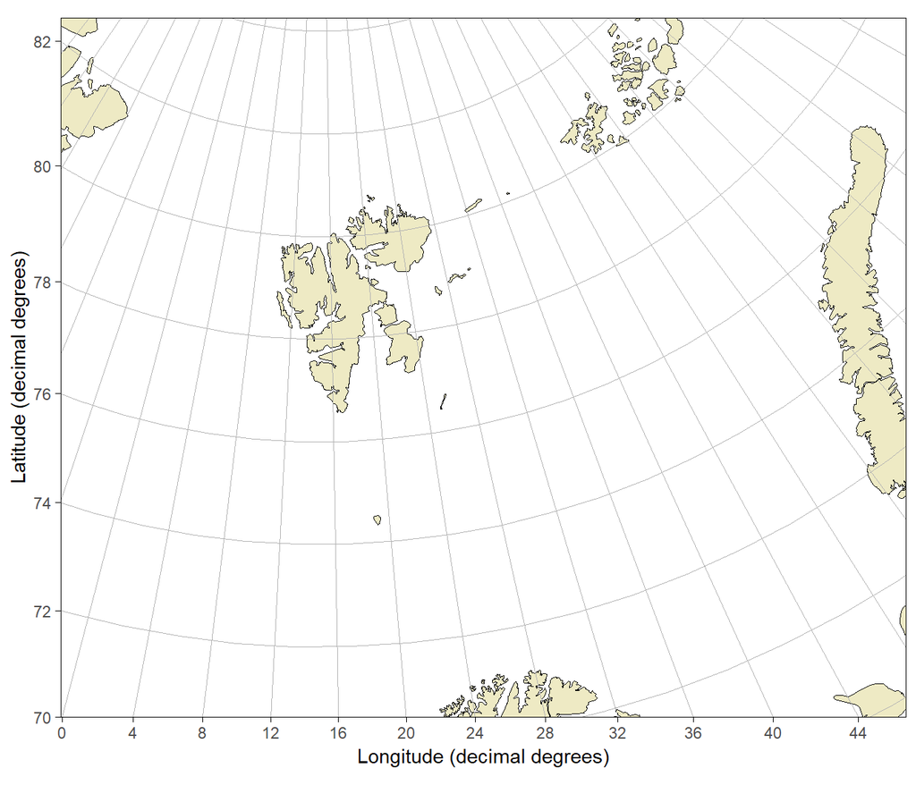

```r
basemap("barentssea")
```

Barents Sea map also prints mainland Norway, but the projection is not optimal, and the resolution is quite low.

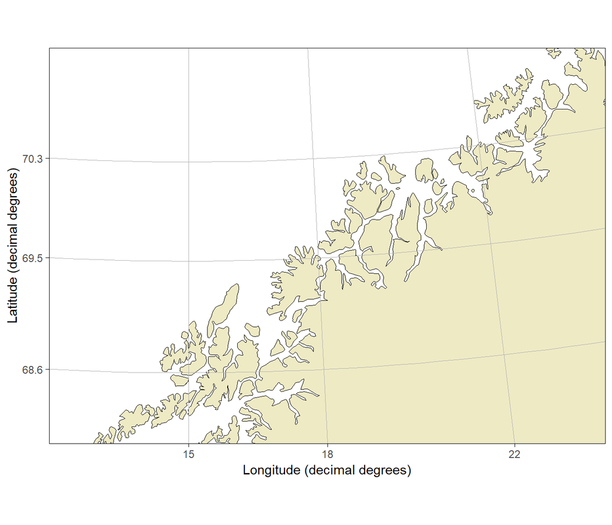

```r
basemap("barentssea", limits = c(12, 24, 68, 71))
```

### Pan-Arctic

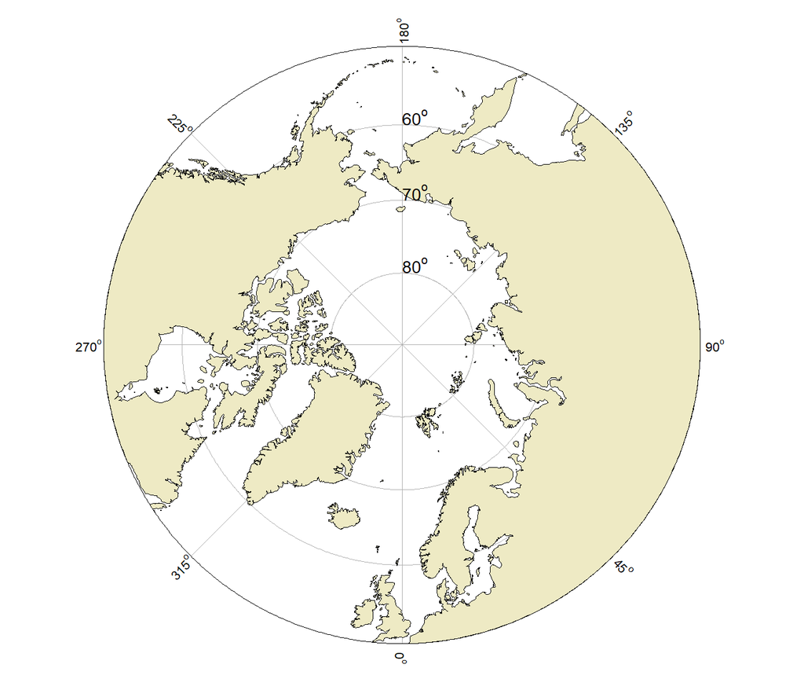

```r
basemap("arctic50")
```

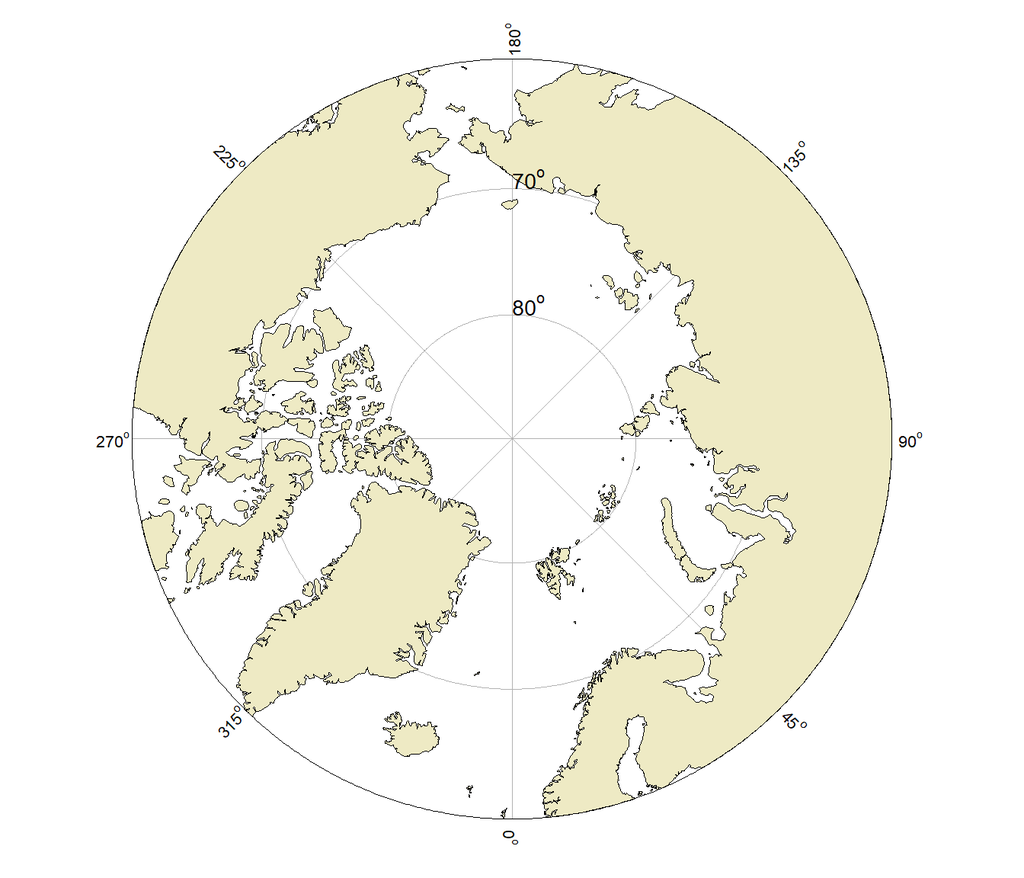

```r
basemap("arctic60")
```

## Limiting (zooming) the maps

Any `basemap` can be limited (or zoomed in) using the `limits` argument. The `limits` argument has to be either a numeric vector of length 4 or a character vector of length 3. Numeric vectors are used to constrain (zoom in) the maps using coordinates. Character vectors are used to automatically zoom into a dataset.

### Manual limits

Achieved using a numeric vector. The first element defines the minimum longitude, the second element the maximum longitude, the third element the minimum latitude and the fourth element the maximum latitude of the bounding box. The coordinates have to be given as decimal degrees for Svalbard and Barents Sea maps and as UTM coordinates for pan-Arctic maps (see [`?transform_coord`](https://mikkovihtakari.github.io/PlotSvalbard/reference/transform_coord.html)).

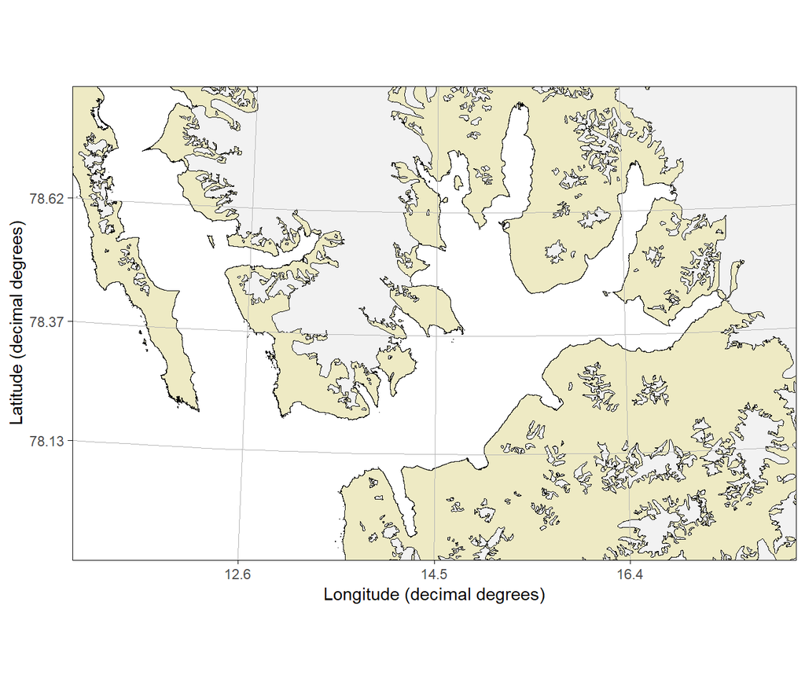

```r
basemap("svalbard", limits = c(11, 18, 77.9, 78.85)) # limits in decimal degrees
```

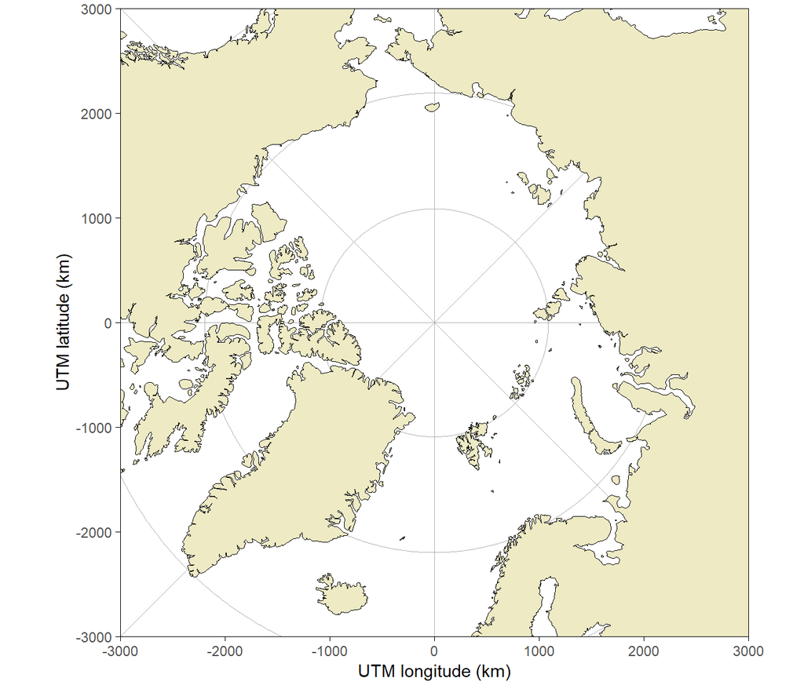

```r
basemap("arctic50", limits = c(3*10^6, -3*10^6, 3*10^6, -3*10^6)) # limits in uTM coordinates
```

Note that some map types are already limited, so if you are looking for a map of Kongsfjorden, using `basemap("kongsfjorden")` might be just what you need.

### Automatic limits

Requires a character vector: the first element gives the object name of the data frame containing data to which the map should be limited, the second argument gives the column name of longitude data and the third argument the column name of latitude data. The map will be limited using rounded minimum and maximum floor and ceiling values for longitude and latitude. Use the `limits.lon` and `limits.lat` agruments to define the accuracy of rounding.

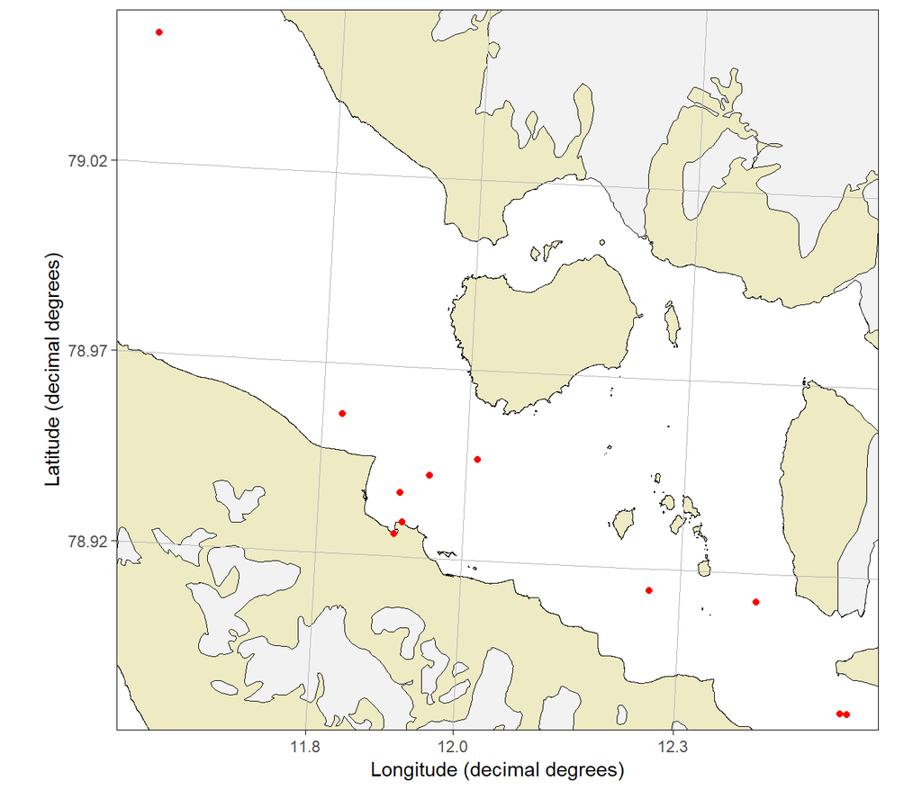

```r
basemap(type = "svalbard", limits = c("kongsfjord_moorings", "Lon", "Lat"), limits.lon = 0.01, limits.lat = 0.01) + geom_point(data = kongsfjord_moorings, aes(x = lon.utm, y = lat.utm), color = "red")
```

## Bathymetry

All basemaps support bathymetry, but the resolution of bathymetry shapefiles is varying. Bathymetry can be plotted using the `bathymetry` argument.

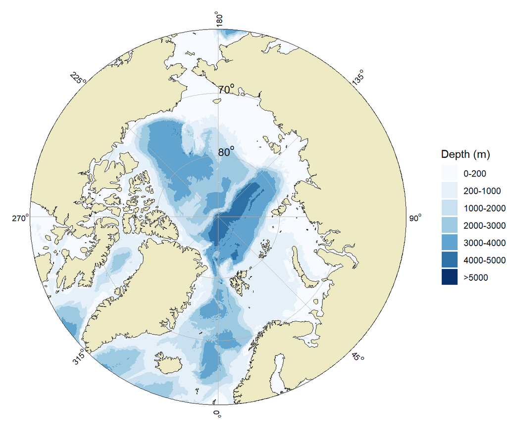

```r
basemap("arctic60", bathymetry = TRUE)
```

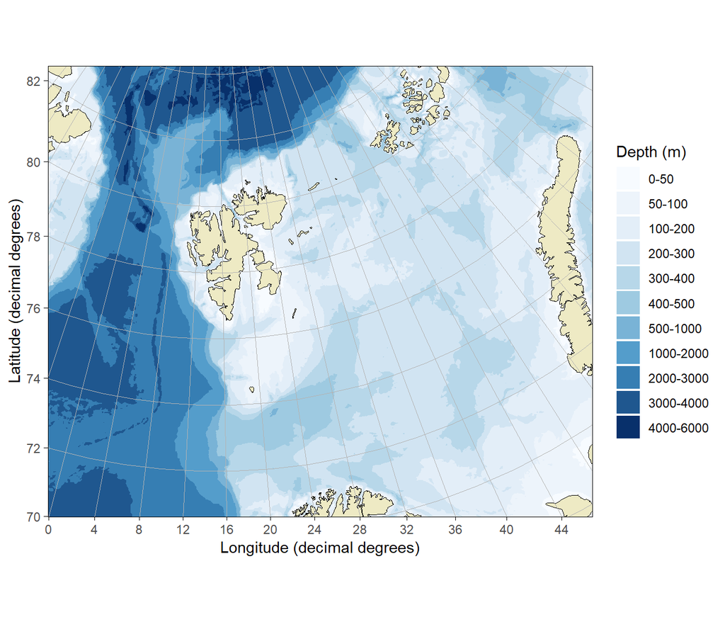

```r
basemap("barentssea", bathymetry = TRUE)
```

### Detailed bathymetry shapes

The default bathymetry shapefile is too low resolution to be used inside Svalbard fjords:

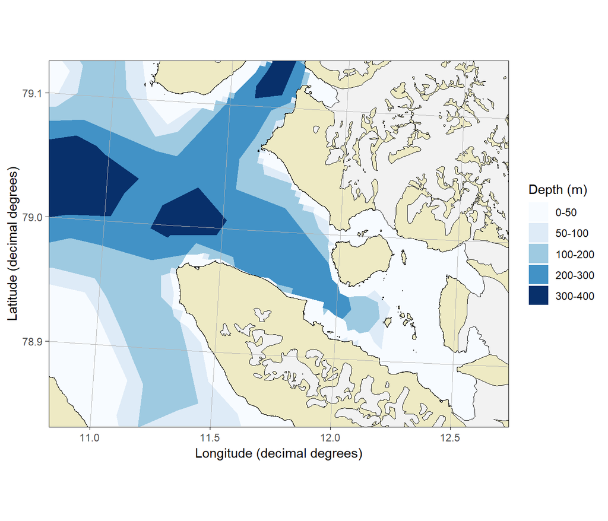

```r
basemap("kongsfjorden", bathymetry = TRUE)
```

PlotSvalbard contains more detailed shapefiles from the Norwegian Mapping Authority, but these files have gaps in them. More detailed shapefiles can be plotted using the `bathy.detailed` argument (warning: detailed bathymetries are large and therefore slow.)

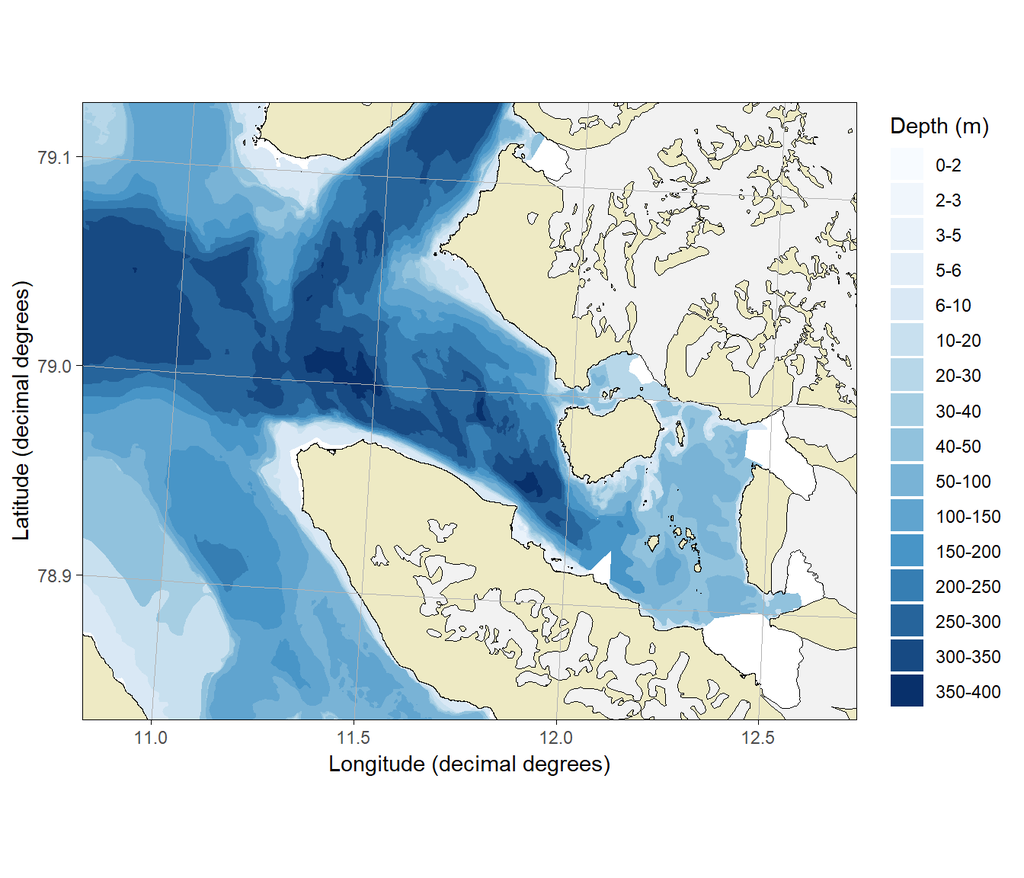

```r
basemap("kongsfjorden", bathymetry = TRUE, bathy.detailed = TRUE)
```

### Bathymetry styles

PlotSvalbard has 4 preprogrammed style alternatives:

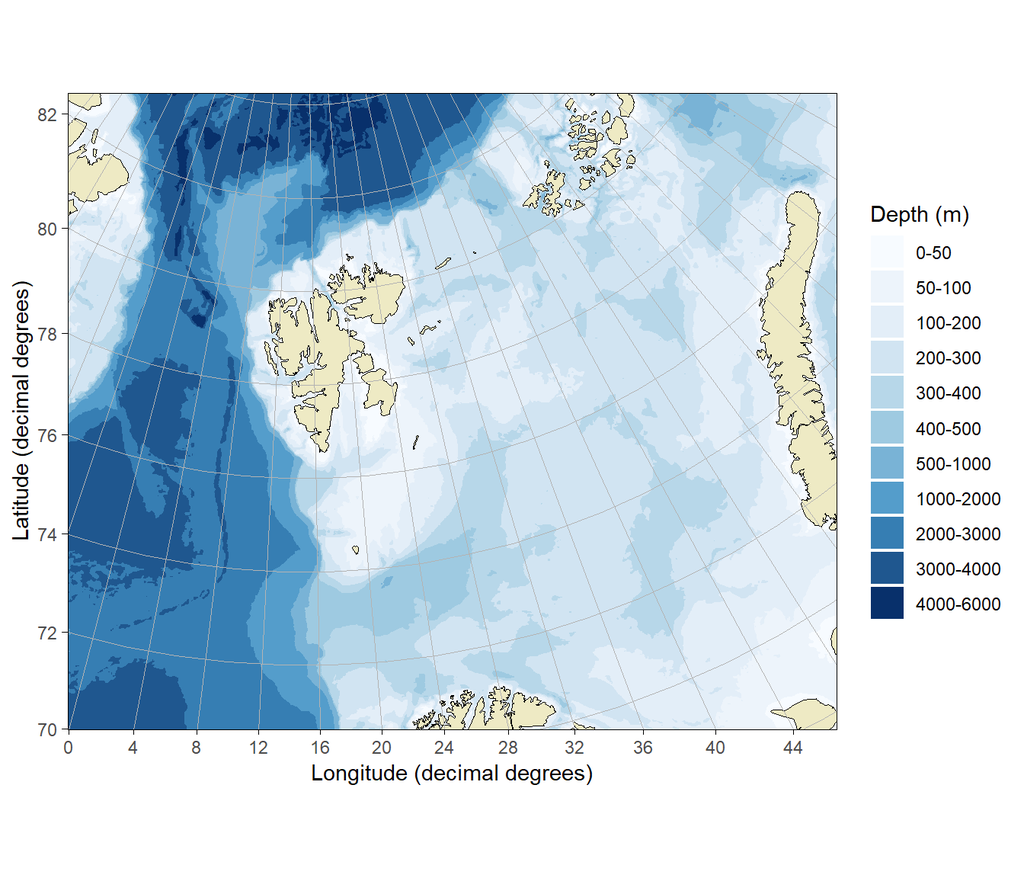

```r
basemap("barentssea", bathymetry = TRUE, bathy.style = "poly_blues") # default
```

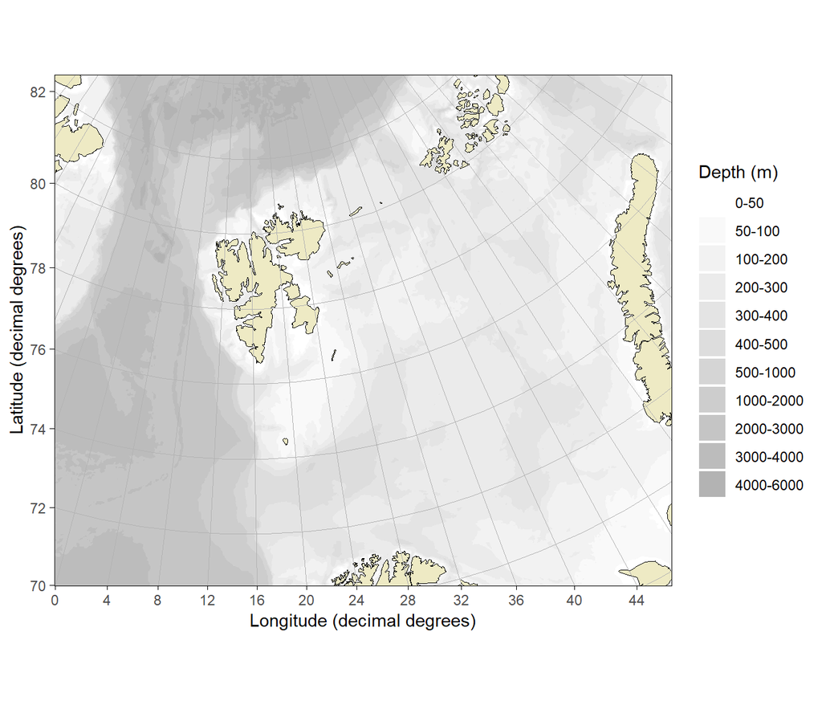

```r
basemap("barentssea", bathymetry = TRUE, bathy.style = "poly_greys") # grey polygons with shading
```

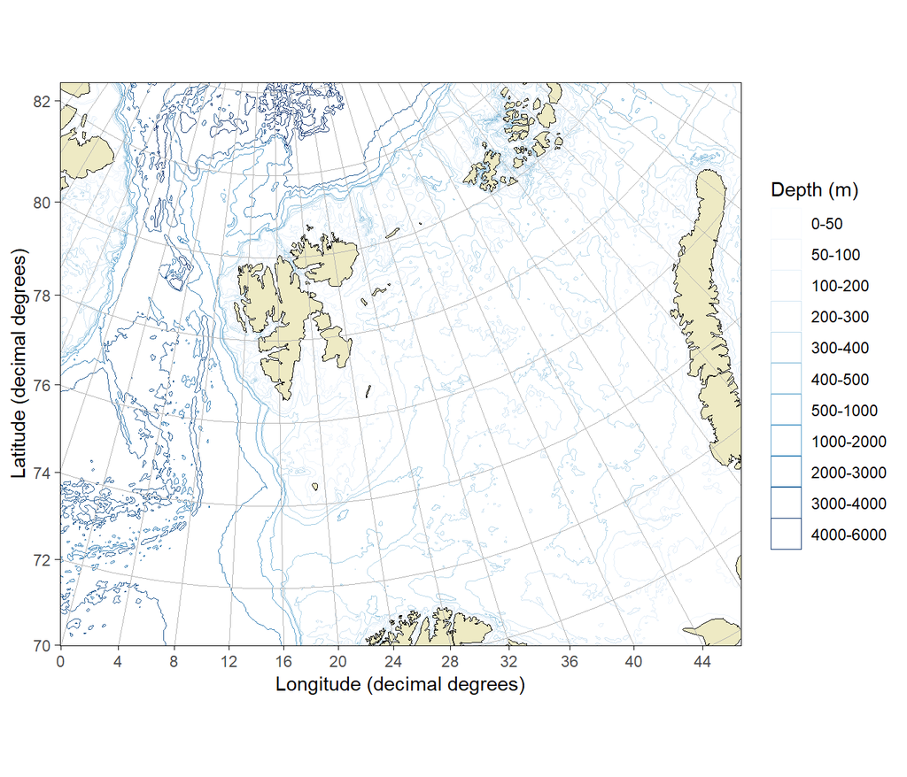

```r
basemap("barentssea", bathymetry = TRUE, bathy.style = "contour_blues") # colored contours
```

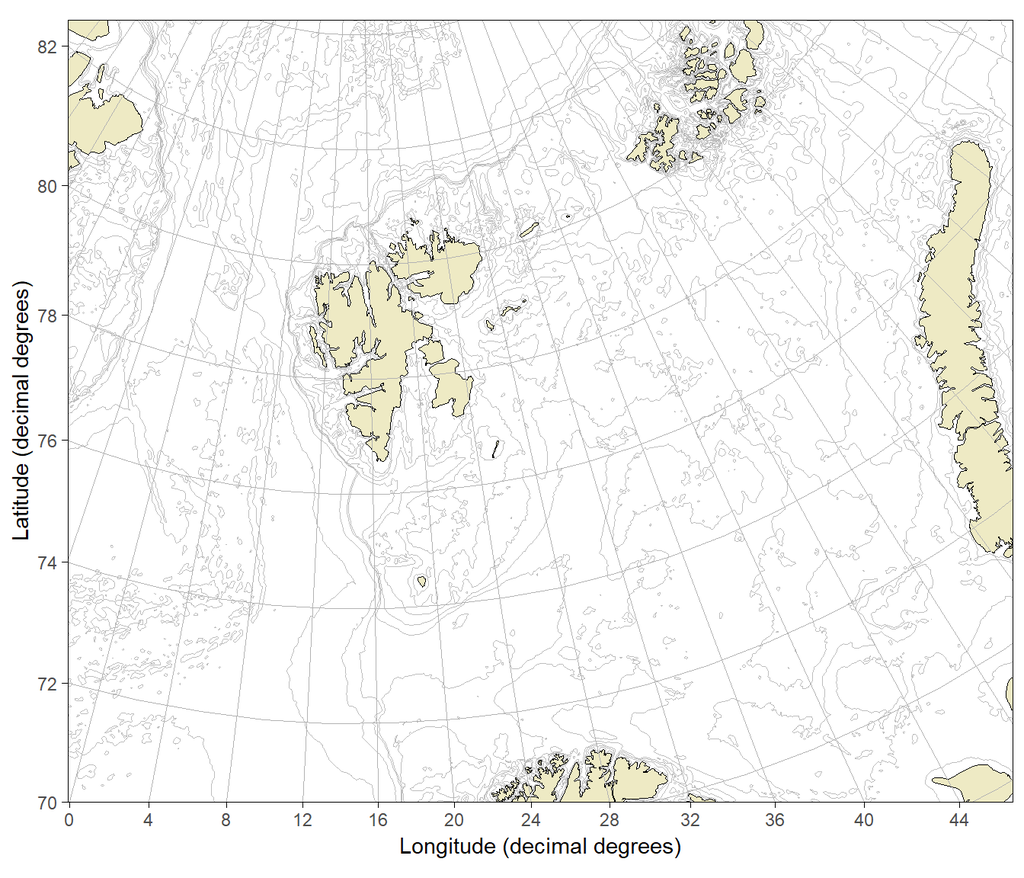

```r
basemap("barentssea", bathymetry = TRUE, bathy.style = "contour_grey") # grey contours
```

Adding depth labels to contours (ala nautical maps) is currently an unresolved issue.

### Customizing bathymetry styles

The color scales for polygons and contours can be adjusted using ggplot2 syntax:

```r
basemap("barentssea", bathymetry = TRUE) + scale_fill_viridis_d("Water depth (m)")
```

[output not shown]

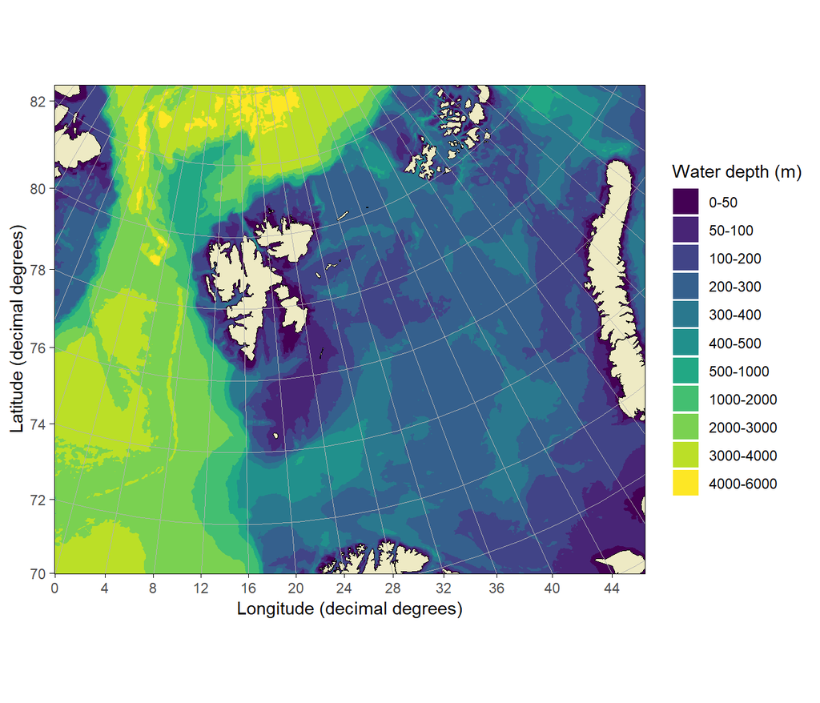

[output not shown]

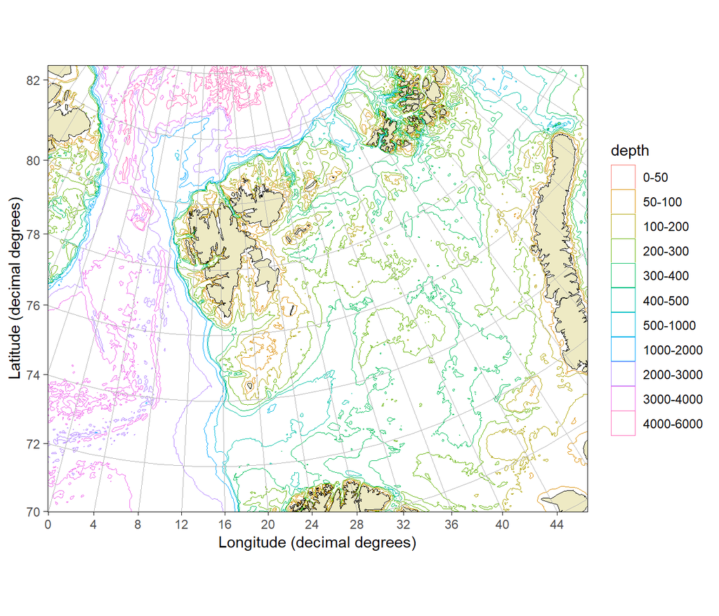

```r
basemap("barentssea", bathymetry = TRUE, bathy.style = "contour_blues") + scale_color_hue()
```

## Ocean currents

Ocean currents for the Barents Sea have been implemented in the most recent version, but not peer-reviewed yet. This feature will be improved in the future versions of the package. Atlantic and Arctic currents are represented using red and purple arrows, respectively. The arrow color can be changed using `atl.color` and `arc.color` arguments.

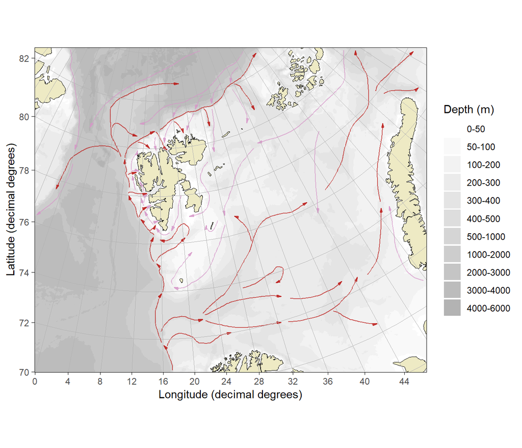

```r
basemap("barentssea", bathymetry = TRUE, bathy.style = "poly_greys", currents = TRUE, current.alpha = 0.7)
```

## Adding data to basemaps

Data can be added to basemaps using the [`+` operator and layers for ggplot2](http://ggplot2.tidyverse.org/reference/). Below you will find some examples on how to add your research data on basemaps.

### Adding station labels (text)

Text can be added to basemaps using the `geom_text()` function:

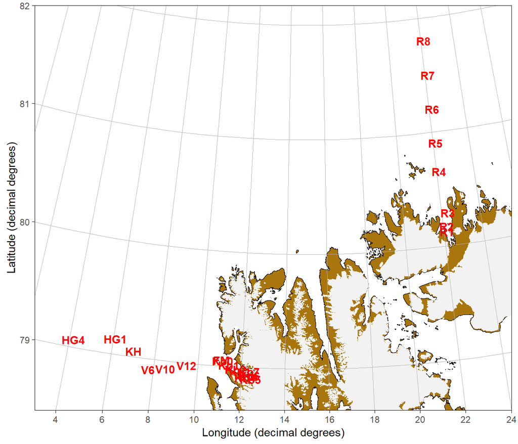

```r
data("npi_stations")

x <- transform_coord(npi_stations, lon = "Lon", lat = "Lat", bind = TRUE)

basemap("svalbard", limits = c(3,24,78.5,82), round.lat = 1, round.lon = 2,
  land.col = "#a9750d", gla.border.col = "grey95") +
  geom_text(data = x, aes(x = lon.utm, y = lat.utm,
    label = Station), color = "red", fontface = 2)
```

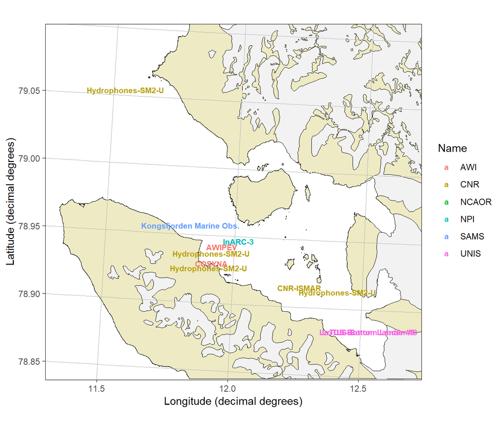

```r
data("kongsfjord_moorings")

basemap("kongsfjorden", limits = c(11.3, 12.69, 78.85, 79.1), round.lat = 0.05, round.lon = 0.5) +
  geom_text(data = kongsfjord_moorings, aes(x = lon.utm, y = lat.utm,
  label = Mooring.name, color = Name), fontface = 2,
  size = 25.4/72.27*8) # font size = 8, see Graphical parameters
```

### Adding piecharts

The [`scatterpie`](https://cran.r-project.org/web/packages/scatterpie/index.html) package allows relatively easy plotting of piecharts on maps. Extensions for ggplot2 work together with PlotSvalbard.

```r
data(zooplankton)

x <- transform_coord(zooplankton, lon = "Longitude", lat = "Latitude", bind = TRUE)

species <- colnames(x)[!colnames(x) %in% c("lon.utm", "lat.utm", "ID",
  "Longitude", "Latitude", "Total")]

library(scatterpie)
```

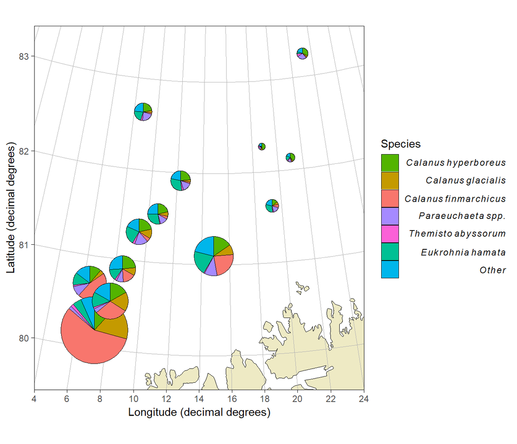

```r
basemap("barentssea", limits = c(4, 24, 79.5, 83.5), round.lon = 2, round.lat = 1) +
  geom_scatterpie(aes(x = lon.utm, y = lat.utm, group = ID, r = 100*Total),
  data = x, cols = species, size = 0.1) + scale_fill_discrete(name = "Species",
  breaks = species, labels = parse(text = paste0("italic(" , sub("*\\.", "~", species), ")")))
```

### Adding interpolated 2D surfaces

PlotSvalbard uses the [`krige` function](https://www.rdocumentation.org/packages/gstat/versions/1.1-5/topics/krige) from the [**gstat** package](https://cran.r-project.org/web/packages/gstat/index.html) to produce interpolated 2D plots:

```r
data("chlorophyll")

x <- interpolate(chlorophyll, Subset = "From <= 10", value = "Chla") ## Interpolate
```

```
#> [inverse distance weighted interpolation]
```

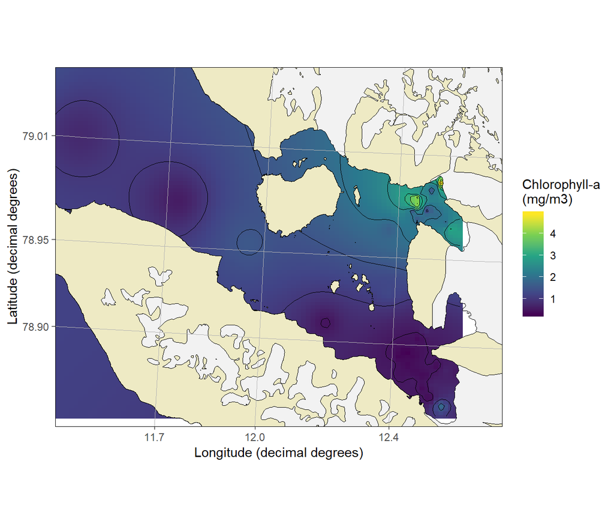

```r
plot(x, type = "kongsfjorden", limits = c(11.4,12.7,78.855,79.05),
  legend.label = "Chlorophyll-a\n(mg/m3)")
```

## Graphical parameters

The line widths and general looks of the basemaps are optimized for a half page sized `pdf` figure in scientific journals ([Springer figure dimensions](http://www.springer.com/authors/manuscript+guidelines?SGWID=0-40162-6-795162-0) were used to develop the function). The line widths may not look good when printed on other devices. You can modify the line widths and colors using `*.size` and `*.border.col` arguments.

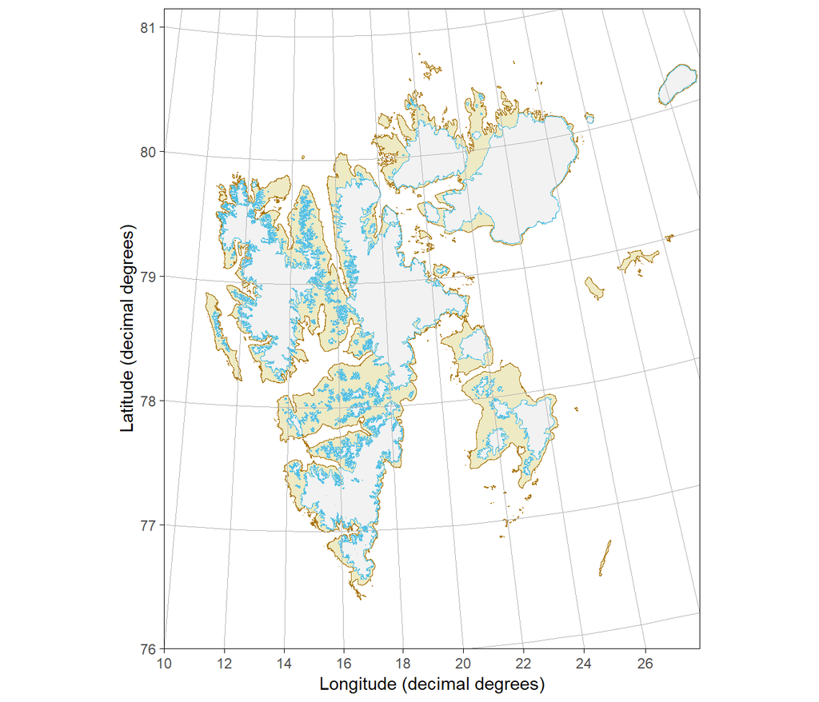

```r
basemap("svalbard", land.size = 0.01, gla.size = 0.05, grid.size = 0.05,
  gla.border.col = "#52bfe4", land.border.col = "#a9750d")
```

Approach to remove borders of land and glacier shapes:

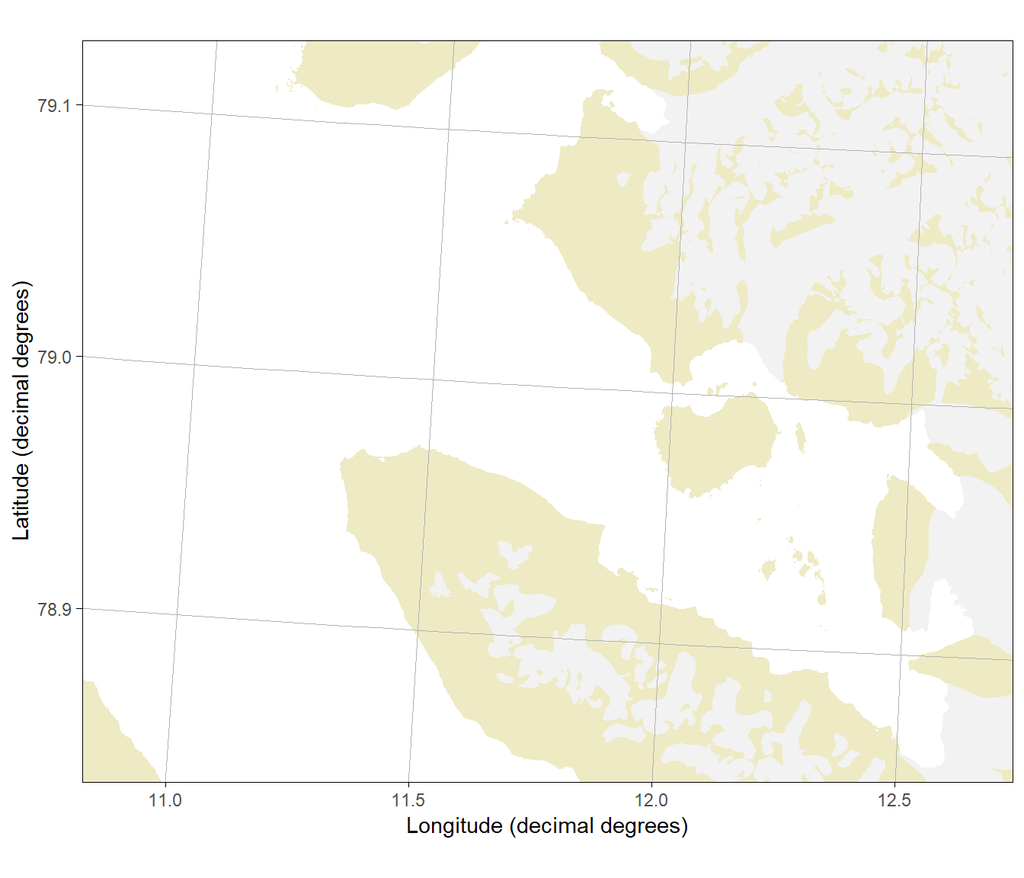

```r
basemap("kongsfjorden", gla.border.col = "grey95", land.border.col = "#eeeac4")
```

The [line width of ggplot2 is 2.13 wider than the line widths measured as points](https://stackoverflow.com/questions/47519624/how-is-the-line-width-size-defined-in-ggplot2/47521808#47521808) (pt). This means that if you want a certain line width, multiply the desired line width by $1/2.13$ inside `size.*` arguments. Similar conversion factor for font size is $1/2.845276$.

## Performance

The `basemap("svalbard")` is currently fairly slow due to less than optimized code and the large size of the shapefiles that are used to generate the map. Zoomed in maps are considerably faster than full scale Svalbard maps.

If you are looking for optimal `limits` for your data, you can use the `basemap("barentssea")` option to find these limits and replace `"barentssea"` with `"svalbard"` once you are done:

```r
system.time(basemap("barentssea"))
```

```
#>    user  system elapsed
#>    0.43    0.02    0.61
```

```r
system.time(basemap("svalbard"))
```

```
#>    user  system elapsed
#>   25.83    0.28   26.69
```

```r
system.time(basemap("barentssea", limits = c(c(19.5,23.5,80,81.7))))
```

```
#>    user  system elapsed
#>    0.19    0.02    0.20
```

```r
system.time(basemap("svalbard", limits = c(c(19.5,23.5,80,81.7))))
```

```
#>    user  system elapsed
#>    2.78    0.09    2.93
```

# Other functions

## Distance to land

The [`dist2land`](https://mikkovihtakari.github.io/PlotSvalbard/reference/dist2land.html) function calculates the closest distance to land.

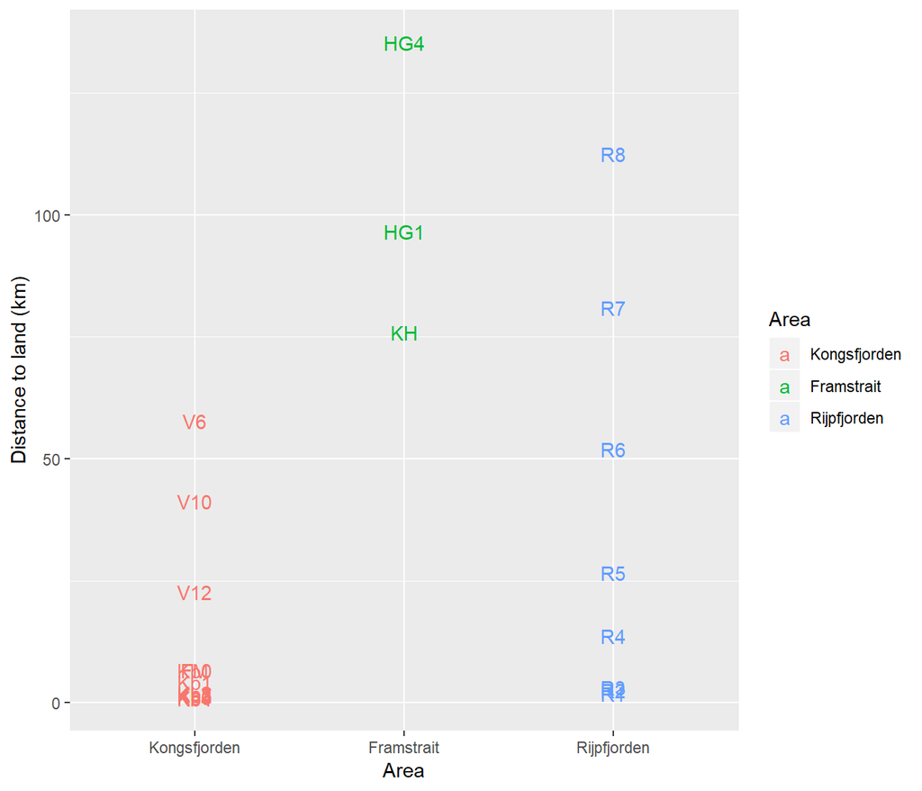

```r
library(ggplot2)
data("npi_stations")

dists <- dist2land(npi_stations, lon.col = "Lon", lat.col = "Lat", map.type = "svalbard")
dists$Area <- ordered(dists$Area, c("Kongsfjorden", "Framstrait", "Rijpfjorden"))

ggplot(dists, aes(x = Area, y = dist, label = Station, color = Area)) +
  geom_text() + ylab("Distance to land (km)") + scale_color_hue()
```

## Waffle charts

Code for waffle charts has been recently implemented into the package and will be extended to enable plotting the waffles on maps. Currently the waffle plotting on maps has to be done manually using the `grid`and `gridExtra` packages (see StackOverflow how to do this). Waffle charts are filled from bottom upwards and from left to right:

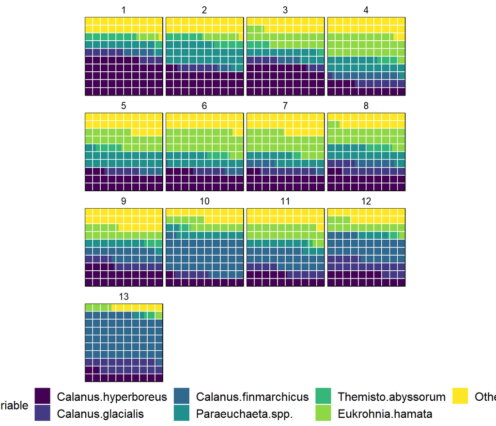

```r
library(reshape2)
data("zooplankton")

# Remove coordinates
x <- zooplankton[!names(zooplankton) %in% c("Longitude", "Latitude")]

## Make get the absolute values
x[!names(x) %in% c("ID", "Total")] <- (x[!names(x) %in% c("ID", "Total")]/100)*x$Total
x <- melt(x, id = c("ID", "Total"))

waffle_chart(x, fill = "variable", facet = "ID")
```

The waffles can also be scaled to maximum values

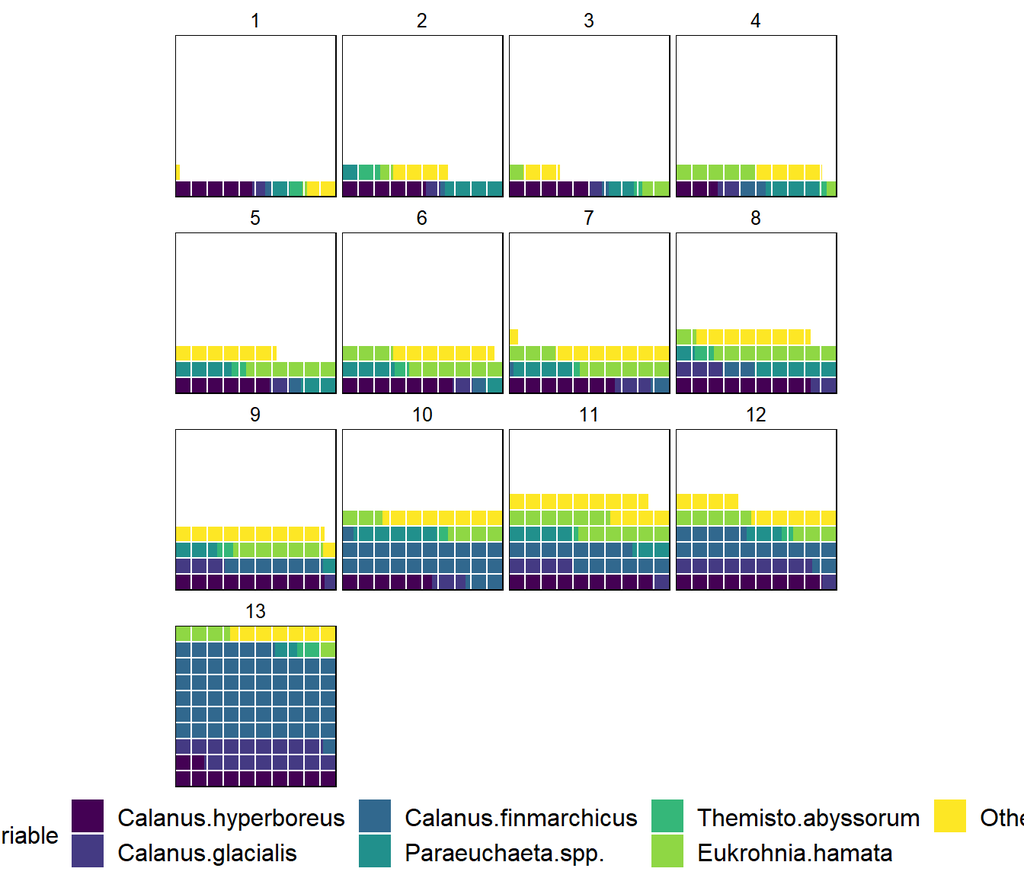

```r
library(dplyr)

y <- x %>% group_by(ID) %>% summarise(sum = sum(value))

waffle_chart(x, fill = "variable", facet = "ID", composition = FALSE, max_value = max(y$sum))
```

# Citing PlotSvalbard

The `citation` function tells how to cite PlotSvalbard package

```r
citation("PlotSvalbard")
```

```
#>
#>
#>   Mikko Vihtakari (2018). PlotSvalbard: PlotSvalbard - Plot
#>   research data from Svalbard on maps. R package version 0.5.0.
#>   https://github.com/MikkoVihtakari/PlotSvalbard
#>
#> A BibTeX entry for LaTeX users is
#>
#>   @Manual{,
#>     title = {PlotSvalbard: PlotSvalbard - Plot research data from Svalbard on maps},
#>     author = {Mikko Vihtakari},
#>     year = {2018},
#>     note = {R package version 0.5.0},
#>     url = {https://github.com/MikkoVihtakari/PlotSvalbard},
#>   }
```

However, please note that the maps generated by this package should be cited to their original source.

- Svalbard maps originate from the [Norwegian Polar Institute](http://geodata.npolar.no/). Distributed under the [CC BY 4.0 license](https://creativecommons.org/licenses/by/4.0/) ([terms of use](http://geodata.npolar.no/bruksvilkar/)).
- Barents Sea and pan-Arctic maps are downloaded from [Natural Earth Data](http://www.naturalearthdata.com). They use the [ne_10m_land](http://www.naturalearthdata.com/downloads/10m-physical-vectors/) and [ne_50m_land](http://www.naturalearthdata.com/downloads/50m-physical-vectors/) (v 4.0.0) datasets, respectively. Distributed under the [CC Public Domain license](https://creativecommons.org/publicdomain/) ([terms of use](http://www.naturalearthdata.com/about/terms-of-use/)).
- Pan-Arctic and Barents Sea bathymetry shapefiles are generalized from [IBCAO v3.0 500m RR grid](https://www.ngdc.noaa.gov/mgg/bathymetry/arctic/ibcaoversion3.html). Should be cited as [Jakobsson, M., et al. The International Bathymetric Chart of the Arctic Ocean (IBCAO) Version 3.0. Geophys. Res. Lett. 2012, 39:L12609.](https://www.ngdc.noaa.gov/mgg/bathymetry/arctic/2012GL052219.pdf)
- Svalbard fjord bathymetry shapefiles are from the [Norwegian Mapping Authority](https://kartkatalog.geonorge.no/metadata/kartverket/dybdedata/2751aacf-5472-4850-a208-3532a51c529a). Distributed under the [CC BY 4.0 license](https://creativecommons.org/licenses/by/4.0/).

The example data included in the package are property of the Norwegian Polar Institute and should not be used in other instances. I.e. these data are unpublihed at the moment.

PlotSvalbard depends on many packages (see [**Dependencies**](https://mikkovihtakari.github.io/PlotSvalbard/index.html#dependencies)). If you use these packages in your publications, please cite the respective packages.